# 20040101006_Eda İpek_Sanlı_BM_VM

Eda İpek SANLI - 20040101006  
İstanbul Topkapı Üniversitesi  
Mühendislik Fakültesi  
Bilgisayar Mühendisliği  
Veri Madenciliği (FET308)  
Sajjad Nematzadeh Miandoab

Veri seti linki: https://www.kaggle.com/datasets/fatihb/coffee-quality-data-cqi?resource=download

**Veri Seti Hakkında Bilgiler**  
Verileri Coffee Quality Institute'ten alan "Coffee Quality Data" veri seti, arabica türü kahve üretimi, işlenmesi ve duyusal analize ilişkin çeşitli veriler içermektedir. Aynı zamanda kahve genetiği, toprak türleri ve kahve kalitesini etkileyebilecek diğer faktörlere ilişkin verileri de içerir. CQI dünya çapında kahvenin kalitesini ve değerini artırmak için çalışan, kar amacı gütmeyen bir kuruluştur. 1996 yılında kurulmuştur ve merkezi ABD'nin Kaliforniya eyaletinde bulunmaktadır.  
**Kahve Kalitesi Hakkındaki Değişkenlerin Bilgileri**  
-Aroma: Kahvenin kokusunu veya kokusunu ifade eder.  
-Lezzet: Kahvenin tadı, tatlılık, acılık, asitlik ve diğer tat notları da dahil olmak üzere tada göre değerlendirilir.  
-Ağızda Kalan Tat: Kahveyi yuttuktan sonra ağızda kalan tadı ifade eder.  
-Asitlik: Kahvedeki asitlik, tadın parlaklığını veya canlılığını ifade eder.  
-Gövde: Kahvenin gövdesi, kahvenin ağızdaki kalınlığını veya viskozitesini ifade eder.  
-Denge: Denge, kahvenin farklı lezzet bileşenlerinin birlikte ne kadar iyi çalıştığını ifade eder.  
-Tekdüzelik: Tekdüzelik, kahvenin fincandan fincana tutarlılığını ifade eder.  
-Temiz Fincan: Temiz fincan, ekşilik, küflenme veya bayatlık gibi herhangi bir kötü tat veya kusur içermeyen kahveyi ifade eder.  
-Tatlılık: Karamel benzeri, meyvemsi veya çiçeksi olarak tanımlanabilir ve kahvede arzu edilen bir kalitedir.

**Defects(Kusurlar)**  
Kusurlar, kahve çekirdeklerinde işleme veya depolama sırasında oluşabilecek istenmeyen niteliklerdir. Kusurlar iki kategoriye ayrılabilir: Kategori bir ve kategori iki kusurlar.  
-Kategori Bir kusurlar, kahve çekirdeklerinin görsel olarak incelenmesiyle algılanabilen birincil kusurlardır. Bu kusurlar arasında Siyah fasulye, ekşi fasulye, böceklerden zarar görmüş fasulye, mantardan zarar görmüş fasulye vb. bulunur.  
-Kategori İki kusurlar, daha incelikli olan ve yalnızca tadım yoluyla tespit edilebilen ikincil kusurlardır. Bu kusurlar arasında aşırı fermantasyon, bayatlık, kokuşmuşluk, kimyasal tat vb. yer alır.

```python
import pandas as pd
import matplotlib.pyplot as plt
import seaborn as sns
import numpy as np
from sklearn.model_selection import train_test_split
from sklearn.metrics import mean_absolute_error, mean_squared_error, r2_score
from sklearn.linear_model import LinearRegression
from sklearn.ensemble import RandomForestRegressor
from scipy.stats import ttest_ind
```

```python
df = pd.read_csv("df_arabica_clean.csv")
df.head(5)
```

|  | Unnamed: 0 | ID | Country of Origin | Farm Name | Lot Number | Mill | ICO Number | Company | Altitude | Region | ... | Total Cup Points | Moisture Percentage | Category One Defects | Quakers | Color | Category Two Defects | Expiration | Certification Body | Certification Address | Certification Contact |
| --- | --- | --- | --- | --- | --- | --- | --- | --- | --- | --- | --- | --- | --- | --- | --- | --- | --- | --- | --- | --- | --- |
| 0 | 0 | 0 | Colombia | Finca El Paraiso | CQU2022015 | Finca El Paraiso | NaN | Coffee Quality Union | 1700-1930 | Piendamo,Cauca | ... | 89.33 | 11.8 | 0 | 0 | green | 3 | September 21st, 2023 | Japan Coffee Exchange | 〒413-0002 静岡県熱海市伊豆山１１７３−５８ 1173-58 Izusan, Ata... | 松澤 宏樹 Koju Matsuzawa - +81(0)9085642901 |
| 1 | 1 | 1 | Taiwan | Royal Bean Geisha Estate | The 2022 Pacific Rim Coffee Summit,T037 | Royal Bean Geisha Estate | NaN | Taiwan Coffee Laboratory | 1200 | Chiayi | ... | 87.58 | 10.5 | 0 | 0 | blue-green | 0 | November 15th, 2023 | Taiwan Coffee Laboratory 台灣咖啡研究室 | QAHWAH CO., LTD 4F, No. 225, Sec. 3, Beixin Rd... | Lin, Jen-An Neil 林仁安 - 886-289116612 |
| 2 | 2 | 2 | Laos | OKLAO coffee farms | The 2022 Pacific Rim Coffee Summit,LA01 | oklao coffee processing plant | NaN | Taiwan Coffee Laboratory | 1300 | Laos Borofen Plateau | ... | 87.42 | 10.4 | 0 | 0 | yellowish | 2 | November 15th, 2023 | Taiwan Coffee Laboratory 台灣咖啡研究室 | QAHWAH CO., LTD 4F, No. 225, Sec. 3, Beixin Rd... | Lin, Jen-An Neil 林仁安 - 886-289116612 |
| 3 | 3 | 3 | Costa Rica | La Cumbre | CQU2022017 | La Montana Tarrazu MIll | NaN | Coffee Quality Union | 1900 | Los Santos,Tarrazu | ... | 87.17 | 11.8 | 0 | 0 | green | 0 | September 21st, 2023 | Japan Coffee Exchange | 〒413-0002 静岡県熱海市伊豆山１１７３−５８ 1173-58 Izusan, Ata... | 松澤 宏樹 Koju Matsuzawa - +81(0)9085642901 |
| 4 | 4 | 4 | Colombia | Finca Santuario | CQU2023002 | Finca Santuario | NaN | Coffee Quality Union | 1850-2100 | Popayan,Cauca | ... | 87.08 | 11.6 | 0 | 2 | yellow-green | 2 | March 5th, 2024 | Japan Coffee Exchange | 〒413-0002 静岡県熱海市伊豆山１１７３−５８ 1173-58 Izusan, Ata... | 松澤 宏樹 Koju Matsuzawa - +81(0)9085642901 |

5 rows × 41 columns

```python
df.info()
```

```
<class 'pandas.core.frame.DataFrame'>
RangeIndex: 207 entries, 0 to 206
Data columns (total 41 columns):
 #   Column                 Non-Null Count  Dtype
---  ------                 --------------  -----
 0   Unnamed: 0             207 non-null    int64
 1   ID                     207 non-null    int64
 2   Country of Origin      207 non-null    object
 3   Farm Name              205 non-null    object
 4   Lot Number             206 non-null    object
 5   Mill                   204 non-null    object
 6   ICO Number             75 non-null     object
 7   Company                207 non-null    object
 8   Altitude               206 non-null    object
 9   Region                 205 non-null    object
```

[output cut: 33 more lines]

-Veri seti 41 sütun ve 207 satıra sahip.  
-19 tane nümerik 22 tane kategorik özellik vardır.

```python
#İlk sütünün adını bilmediğimiz, ID'nin kahve kalitesi üzerinde etkisi olmadığı
#ve ICO numarasında sadece 75 değere ulaşabildiğimiz için bu sütunları siliyoruz.
#Ayrıca status sütunu sadece '1' değerini içermektedir.
df.drop(columns=['Unnamed: 0', 'ID','ICO Number','Status'],inplace=True)
#Altitude değeri nümerik olmasına rağmen object veri türünde. Bunu düzeltmek için
#aralık olarak verilen verilerin ortalaması alınıp yazılacak.
import re
def numerik(x):
    x = str(x)
    x = re.findall(r'\d+|\D+', x)
    if len(x) ==3:
        return (int(x[0])+int(x[2]))//2
    elif len(x) == 1 and x[0].isdigit():
        return int(x[0])
    else:
        return -1
df["Altitude"] = df["Altitude"].apply(numerik)
```

```python
df["Altitude"].replace(-1, np.nan, inplace=True)
df["Altitude"].fillna(df["Altitude"].mean(), inplace=True)

df.isnull().sum()
```

```
Country of Origin        0
Farm Name                2
Lot Number               1
Mill                     3
Company                  0
Altitude                 0
Region                   2
Producer                 1
Number of Bags           0
Bag Weight               0
In-Country Partner       0
Harvest Year             0
Grading Date             0
Owner                    0
Variety                  6
Processing Method        5
Aroma                    0
Flavor                   0
Aftertaste               0
Acidity                  0
Body                     0
Balance                  0
Uniformity               0
Clean Cup                0
Sweetness                0
Overall                  0
Defects                  0
Total Cup Points         0
Moisture Percentage      0
Category One Defects     0
Quakers                  0
Color                    0
Category Two Defects     0
Expiration               0
Certification Body       0
Certification Address    0
Certification Contact    0
dtype: int64
```

```python
df.describe().transpose()
```

|  | count | mean | std | min | 25% | 50% | 75% | max |
| --- | --- | --- | --- | --- | --- | --- | --- | --- |
| Altitude | 207.0 | 1311.733010 | 719.737770 | 139.00 | 1020.00 | 1311.73301 | 1600.000 | 5400.00 |
| Number of Bags | 207.0 | 155.449275 | 244.484868 | 1.00 | 1.00 | 14.00000 | 275.000 | 2240.00 |
| Aroma | 207.0 | 7.721063 | 0.287626 | 6.50 | 7.58 | 7.67000 | 7.920 | 8.58 |
| Flavor | 207.0 | 7.744734 | 0.279613 | 6.75 | 7.58 | 7.75000 | 7.920 | 8.50 |
| Aftertaste | 207.0 | 7.599758 | 0.275911 | 6.67 | 7.42 | 7.58000 | 7.750 | 8.42 |
| Acidity | 207.0 | 7.690290 | 0.259510 | 6.83 | 7.50 | 7.67000 | 7.875 | 8.58 |
| Body | 207.0 | 7.640918 | 0.233499 | 6.83 | 7.50 | 7.67000 | 7.750 | 8.25 |
| Balance | 207.0 | 7.644058 | 0.256299 | 6.67 | 7.50 | 7.67000 | 7.790 | 8.42 |
| Uniformity | 207.0 | 9.990338 | 0.103306 | 8.67 | 10.00 | 10.00000 | 10.000 | 10.00 |
| Clean Cup | 207.0 | 10.000000 | 0.000000 | 10.00 | 10.00 | 10.00000 | 10.000 | 10.00 |
| Sweetness | 207.0 | 10.000000 | 0.000000 | 10.00 | 10.00 | 10.00000 | 10.000 | 10.00 |
| Overall | 207.0 | 7.676812 | 0.306359 | 6.67 | 7.50 | 7.67000 | 7.920 | 8.58 |
| Defects | 207.0 | 0.000000 | 0.000000 | 0.00 | 0.00 | 0.00000 | 0.000 | 0.00 |
| Total Cup Points | 207.0 | 83.706570 | 1.730417 | 78.00 | 82.58 | 83.75000 | 84.830 | 89.33 |
| Moisture Percentage | 207.0 | 10.735266 | 1.247468 | 0.00 | 10.10 | 10.80000 | 11.500 | 13.50 |
| Category One Defects | 207.0 | 0.135266 | 0.592070 | 0.00 | 0.00 | 0.00000 | 0.000 | 5.00 |
| Quakers | 207.0 | 0.690821 | 1.686918 | 0.00 | 0.00 | 0.00000 | 1.000 | 12.00 |
| Category Two Defects | 207.0 | 2.251208 | 2.950183 | 0.00 | 0.00 | 1.00000 | 3.000 | 16.00 |

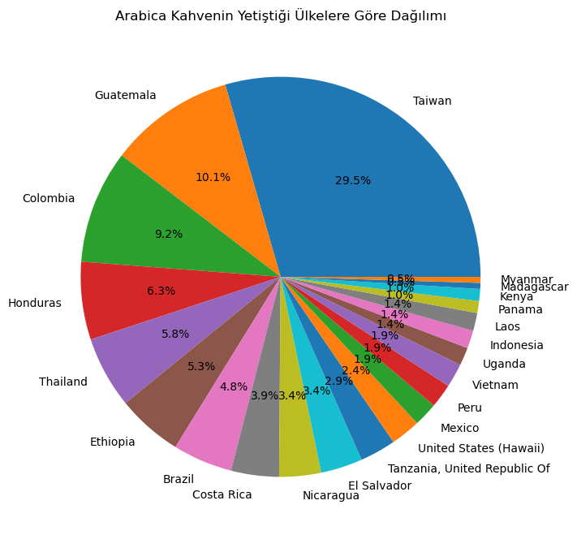

```python
country_counts = df['Country of Origin'].value_counts()
plt.figure(figsize=(8, 8))
country_counts.plot(kind='pie', autopct='%1.1f%%')
plt.title('Arabica Kahvenin Yetiştiği Ülkelere Göre Dağılımı')
plt.ylabel("")
```

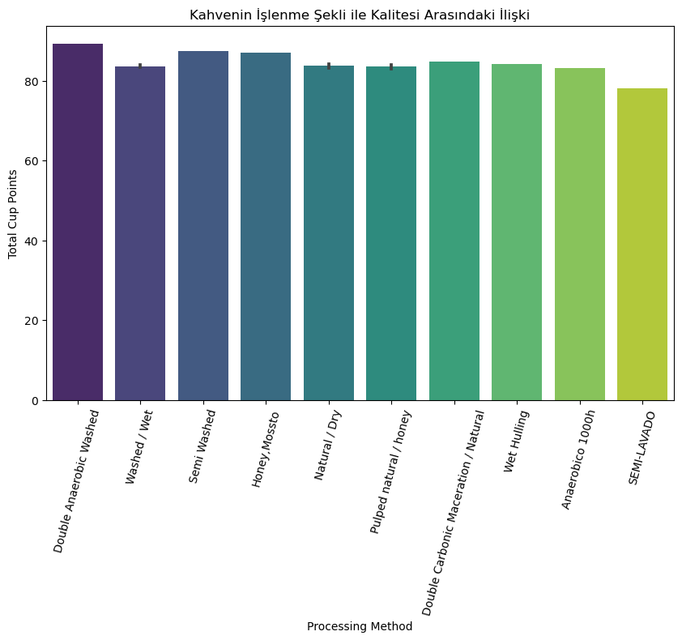

```python
plt.figure(figsize=(10, 6))
sns.barplot(data=df, x='Processing Method', y='Total Cup Points', palette='viridis')

plt.xticks(rotation=75)
plt.xlabel('Processing Method')
plt.ylabel('Total Cup Points')
plt.title('Kahvenin İşlenme Şekli ile Kalitesi Arasındaki İlişki')
plt.show()
```

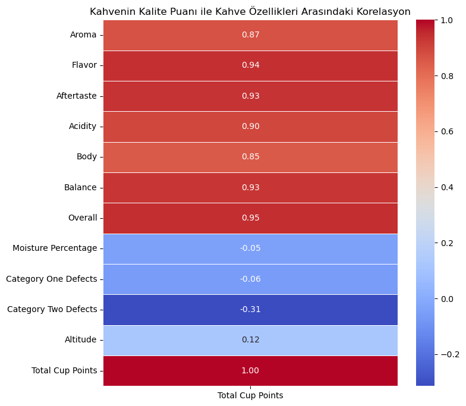

```python
correlation_matrix = df[['Aroma', 'Flavor', 'Aftertaste', 'Acidity', 'Body', 'Balance','Overall','Moisture Percentage','Category One Defects','Category Two Defects','Altitude','Total Cup Points']].corr()

plt.figure(figsize=(8, 8))
sns.heatmap(correlation_matrix[['Total Cup Points']], annot=True, cmap='coolwarm', fmt=".2f", linewidths=.5, cbar_kws={'location': 'right'})
plt.title('Kahvenin Kalite Puanı ile Kahve Özellikleri Arasındaki Korelasyon')
plt.show()
```

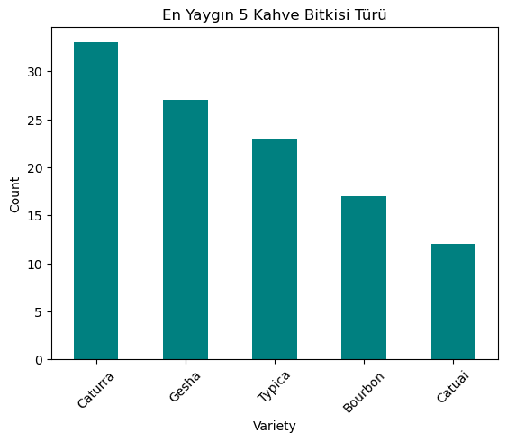

```python
#print(df['Variety'].value_counts())
df['Variety'].fillna(df['Variety'].mode()[0], inplace=True)
ax = df['Variety'].value_counts().head(5).plot(kind='bar', title='Variety Count', color='teal')
ax.set_xlabel('Variety')
ax.set_ylabel('Count')
ax.set_title("En Yaygın 5 Kahve Bitkisi Türü")
plt.xticks(rotation=45)
plt.show()
```

```
Color
green            101
greenish          36
bluish-green      21
blue-green        12
yellow-green      10
brownish           9
pale yellow        6
yellow green       5
yellowish          4
yellow- green      1
browish-green      1
yello-green        1
Name: count, dtype: int64
```

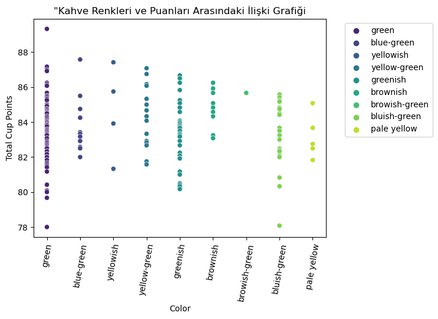

```python
print(df['Color'].value_counts())
#Yanlış yazılmış kategorik verileri düzeltiyoruz
df['Color'] = df['Color'].str.replace('yellow green','yellow-green')
df['Color'] = df['Color'].str.replace('yellow- green','yellow-green')
df['Color'] = df['Color'].str.replace('yello-green','yellow-green')

sns.scatterplot(x='Color', y='Total Cup Points', data=df, hue="Color", palette='viridis')
plt.title('"Kahve Renkleri ve Puanları Arasındaki İlişki Grafiği')
plt.xlabel('Color')
plt.ylabel('Total Cup Points')
plt.xticks(rotation=80)
plt.legend(loc='upper left', bbox_to_anchor=(1.05, 1))
plt.show()
```

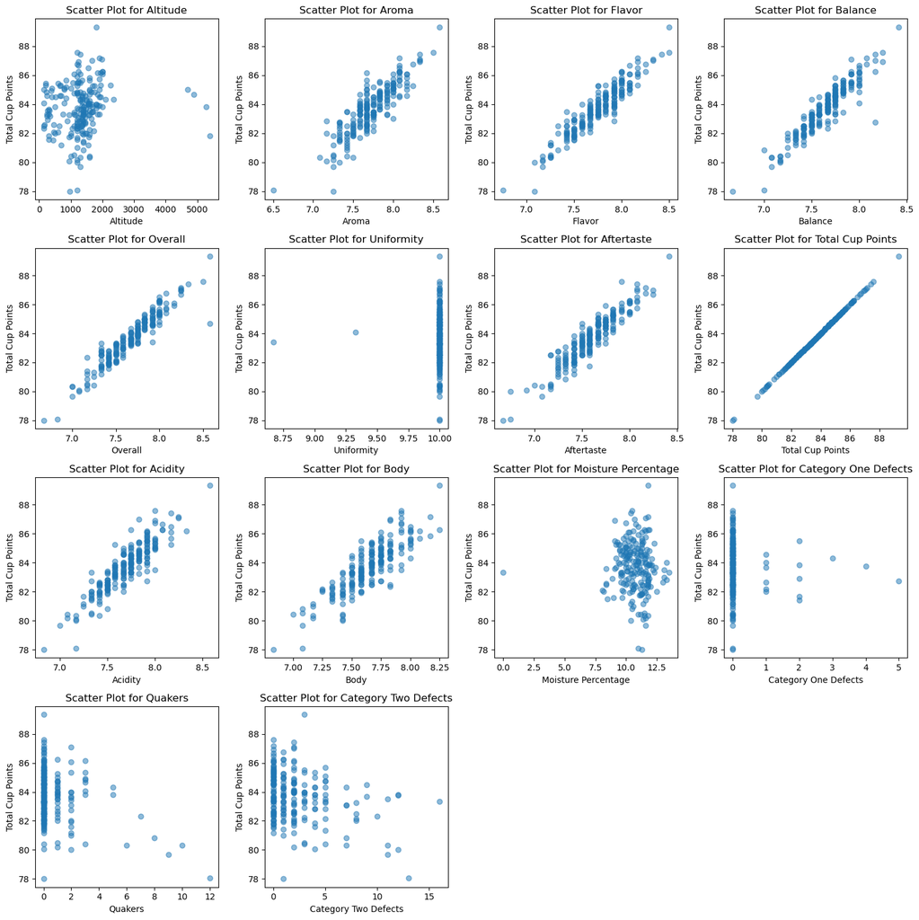

```python
datas = df[['Altitude', 'Aroma','Flavor','Balance','Overall','Uniformity','Aftertaste','Total Cup Points', 'Acidity', 'Body','Moisture Percentage', 'Category One Defects', 'Quakers', 'Category Two Defects']]
features = datas.columns
target_variable = 'Total Cup Points'

subplot_counter = 1

plt.figure(figsize=(15, 15))

for feature in features:
    plt.subplot(4, 4, subplot_counter)
    plt.scatter(datas[feature], df[target_variable], alpha=0.5)
    plt.title(f'Scatter Plot for {feature}')
    plt.xlabel(feature)
    plt.ylabel(target_variable)
    subplot_counter += 1

plt.tight_layout()
plt.show()
```

**Problemin Tanımı:**  
Kahve kalitesini etkileyen faktörleri kullanarak kahve kalitesini tahmin etmek için regresyon analizi yapılmıştır. Veri setindeki çeşitli özellikler, örneğin "Altitude", "Aroma", "Flavor", "Balance", "Overall", "Uniformity", "Aftertaste", "Acidity", "Body", "Moisture Percentage", "Category One Defects", "Quakers", "Category Two Defects", "Country of Origin", "Color", ve "Processing Method", gibi faktörler, bir kahvenin kalitesini belirlemede potansiyel öneme sahip özelliklerdir. Target sütun olarak da 'Total Cup Points' seçilmiştir.

```python
data2 = df[['Altitude', 'Aroma','Flavor','Balance','Overall','Uniformity','Aftertaste','Total Cup Points',
             'Acidity', 'Body','Moisture Percentage', 'Category One Defects', 'Quakers', 'Category Two Defects',
             'Country of Origin', 'Color', 'Processing Method']]
#ML'e uygun olmayan kategorik değerler makinanın anlayacağı dile çeviriliyor.
data2 = pd.get_dummies(data2, columns=['Country of Origin', 'Color', 'Processing Method'], drop_first=True)
data2.info()
```

```
<class 'pandas.core.frame.DataFrame'>
RangeIndex: 207 entries, 0 to 206
Data columns (total 52 columns):
 #   Column                                                  Non-Null Count  Dtype
---  ------                                                  --------------  -----
 0   Altitude                                                207 non-null    float64
 1   Aroma                                                   207 non-null    float64
 2   Flavor                                                  207 non-null    float64
 3   Balance                                                 207 non-null    float64
 4   Overall                                                 207 non-null    float64
 5   Uniformity                                              207 non-null    float64
 6   Aftertaste                                              207 non-null    float64
 7   Total Cup Points                                        207 non-null    float64
 8   Acidity                                                 207 non-null    float64
 9   Body                                                    207 non-null    float64
```

[output cut: 44 more lines]

```python
X = data2.drop('Total Cup Points', axis=1)
y = data2['Total Cup Points']

results_list = []

for _ in range(10):

    X_train, X_test, y_train, y_test = train_test_split(X, y, test_size=0.2)
    model = LinearRegression()

    model.fit(X_train, y_train)

    y_pred = model.predict(X_test)

    mae = mean_absolute_error(y_test, y_pred)
    mse = mean_squared_error(y_test, y_pred)
    rmse = np.sqrt(mse)
    r2 = r2_score(y_test, y_pred)

    results_list.append({'Mean Absolute Error': mae,
                         'Root Mean Square Error': rmse,
                         'R^2 Score': r2})

results_df = pd.DataFrame(results_list)

# Sonuçları yazdır
print(results_df)
```

```
   Mean Absolute Error  Root Mean Square Error  R^2 Score
0             0.008054                0.010242   0.999957
1             0.007508                0.009199   0.999960
2             0.007232                0.008894   0.999974
3             0.008020                0.009541   0.999965
4             0.007225                0.008537   0.999977
5             0.007292                0.009128   0.999977
6             0.008116                0.009631   0.999966
7             0.007368                0.008974   0.999975
8             0.055750                0.231817   0.977766
9             0.007479                0.009177   0.999959
```

```python
results_list_rfr = []
X = data2.drop('Total Cup Points', axis=1)
y = data2['Total Cup Points']
for _ in range(10):

    X_train, X_test, y_train, y_test = train_test_split(X, y, test_size=0.2)
    rf_model = RandomForestRegressor(n_estimators=100)
    rf_model.fit(X_train, y_train)
    y_pred = rf_model.predict(X_test)

    mae = mean_absolute_error(y_test, y_pred)
    mse = mean_squared_error(y_test, y_pred)
    rmse = np.sqrt(mse)
    r2 = r2_score(y_test, y_pred)


    results_list_rfr.append({'Mean Absolute Error': mae,
                         'Root Mean Square Error': rmse,
                         'R^2 Score': r2})

results_df1 = pd.DataFrame(results_list_rfr)

# Sonuçları yazdır
print(results_df1)
```

```
   Mean Absolute Error  Root Mean Square Error  R^2 Score
0             0.170540                0.212606   0.983162
1             0.266540                0.473011   0.926296
2             0.306798                0.477942   0.933824
3             0.239652                0.365535   0.922211
4             0.155505                0.227975   0.977256
5             0.210286                0.347975   0.941608
6             0.225729                0.373794   0.961136
7             0.174645                0.231930   0.984742
8             0.189724                0.229694   0.979641
9             0.261431                0.438700   0.926044
```

```python
mae_model1 = results_df['Mean Absolute Error']
mae_model2 = results_df1['Mean Absolute Error']

t_statistic, p_value = ttest_ind(mae_model1, mae_model2, equal_var=False)

alpha = 0.05
print(f'T-Statistic: {t_statistic}')
print(f'P-Value: {p_value}')

if p_value < alpha:
    print('İki model arasında anlamlı bir fark vardır (H0 reddedildi).')
else:
    print('İki model arasında anlamlı bir fark yoktur (H0 kabul edildi).')
```

```
T-Statistic: -12.82565973846893
P-Value: 7.579073910535286e-08
İki model arasında anlamlı bir fark vardır (H0 reddedildi).
```

```python
rmse_model1 = results_df['Root Mean Square Error']
rmse_model2 = results_df1['Root Mean Square Error']

t_statistic, p_value = ttest_ind(rmse_model1, rmse_model2, equal_var=False)

alpha = 0.05
print(f'T-Statistic: {t_statistic}')
print(f'P-Value: {p_value}')

if p_value < alpha:
    print('İki model arasında anlamlı bir fark vardır (H0 reddedildi).')
else:
    print('İki model arasında anlamlı bir fark yoktur (H0 kabul edildi).')
```

```
T-Statistic: -7.620926891262805
P-Value: 1.1892323406330572e-06
İki model arasında anlamlı bir fark vardır (H0 reddedildi).
```

```python
r2_model1 = results_df['R^2 Score']
r2_model2 = results_df1['R^2 Score']

t_statistic, p_value = ttest_ind(r2_model1, r2_model2, equal_var=False)

alpha = 0.05
print(f'T-Statistic: {t_statistic}')
print(f'P-Value: {p_value}')

if p_value < alpha:
    print('İki model arasında anlamlı bir fark vardır (H0 reddedildi).')
else:
    print('İki model arasında anlamlı bir fark yoktur (H0 kabul edildi).')
```

```
T-Statistic: 5.153548572605698
P-Value: 0.00039189733997211556
İki model arasında anlamlı bir fark vardır (H0 reddedildi).
```

3 t-testine de baktığımızda h0 hipotezinin reddedildiğini görmekteyiz. Bu bize regresyon modelleri arasında anlamlı bir fark olduğunu göstermektedir. RMSE, R^2 ve MAE değerlerine baktığımızda da lineer regresyonun daha iyi sonuç verdiğini görmekteyiz.